# About the Shiny Web App for Estimating future Bitcoin profit

Trenton Potgieter

Sunday, October 19, 2014

### App Overview

This Shiny App estimates the amount of Bitcoins that will be mined, based on forecasting what the Bitcoin Network difficulty will be.

#### Forecast Model Output

After the App is first launched, the default data that is displayed is the output of the **Arima Forecast**. (See **App Background** for further information on the Arima output).

#### Visualizing the Forecast

To see a plot of the model forecast, click on the **Arima Plot** tab.

#### Using the Calculator

1. Enter the current Hashrate produced by the mining hardware. (For Example 4.363).
2. Select whether the number entered is in **kilohashes per second**, **Megahashes per second**, **Gigahashes per second** or **Terahashes per second**.
3. Click the **Submit** Button.

After clicking **Submit**, the **Calculator** tab displays the forcasted Network Difficulty for next 24 months and what the projected amount of Bitcoins (based on that forecasted Network Difficulty) earned for the month, will be.

### App Background

Bitcoin is software that tracks and verifies transactions on a public ledger over a peer-to-peer network. Operations and data associated with Bitcoin are decentralized, meaning they are not performed or stored in one single location. Instead, the Bitcoin network consists of computers across the world that automatically store and relay Bitcoin data to each other. The computers’ owners voluntarily choose to use and run the Bitcoin software. Anyone can use and run Bitcoin software. Bitcoins are produced through a process called mining. Mining is the competitive use of computational power to calculate a number that falls within a certain range. The first miner to discover a number “target”[^1] that meets the criteria is rewarded with a set amount of brand new bitcoins (currently 25 bitcoins), the competition then repeats for the discovery of a new number[^2]. In other words, when the number in the block header is equal or lower than the “target”, the block is accepted by the network and the process to create a new block begins.

Understanding just how difficult[^3] it is to discover the given number below the given target is the key to determining profitability, or measure of success. More importantly is the ability to estimate future mining profitability by predicting what the network difficulty will be. This paper describes the process of forecasting what the network difficulty will be for a two year period and calculating the profitability based on the current hashrate of the mining hardware.

### Methods used in the Shiny App

#### Data Collection

The data used for working with the current and previously recorded Network statistics (including Difficulty) is downloaded directly using the R programming language[^4] from the Bitcoin Network by using the Bitcoin Block Explorer website[^5], which is an open source web tool that allows users to view information about the blocks, addresses, and transactions created by Bitcoin.

```r
options(scipen = 10)
library(shiny)
library(ggplot2)
library(xts)
library(forecast)
library(lubridate)

## Pull the data straight from the website
dt <- read.table("http://blockexplorer.com/q/nethash", header = FALSE,
                 sep = ",", skip = 15)
```

#### Exploratory Data Analysis

Each row within the data is a log containing the following:  
* Time when the block was created (UTC).  
* Decimal target.  
* Difficulty.  
* The average number of hashes it takes to solve a block at this difficulty.

For the process of analysis, Time and Difficulty values are extracted. Any duplicated values are removed and the data is converted from UTC to a standard time format for easier sub setting into monthly periods.

```r
## Extract and convert the Date (in UTC) and Difficulty Value
df <- as.data.frame(as.POSIXct(dt[, 2], origin = '1970-01-01'), format = "%Y/%m/%d")
df[, 2] <- dt[, 5]
names(df) <- c("Date", "Difficulty")
df$Date <- as.Date(as.character(df$Date, format = "%Y-%m-%d"))

## Remove duplicate values
df <- unique(df)
## Create a new xts data.frame
dfXts <- xts(df$Difficulty, df$Date)
```

#### Time-Series Modeling

To model the predicted forecast of the network difficulty, the Arima model is used. Using the auto.arima() function in R uses a variation of the Hyndman and Khandakar[^6] algorithm, which combines unit root tests, minimization of the AICc and MLE to obtain an ARIMA model. The algorithm[^7] follows these steps:

1. The number of differences d is determined using repeated KPSS tests.
2. The values of **p** and **q** are then chosen by minimizing the AICc after differencing the data **d** times. Rather than considering every possible combination of **p** and **q**, the algorithm uses a stepwise search to traverse the model space.
   1. The best model (with smallest AICc) is selected from the following four:ARIMA(2,d,2), ARIMA(0,d,0), ARIMA(1,d,0), ARIMA(0,d,1). If **d=0** then the constant **c** is included; if **d** is greater or equal to **1** then the constant **c** is set to zero. This is called the “current model”.
   2. Variations on the current model are considered:
   - vary **p** and/or **q** from the current model by **+ or - 1**
   - include/exclude **c** from the current model  
     The best model considered so far (either the current model, or one of these variations) becomes the new current model.
3. Repeat Step **2(b)** until no lower AICc can be found.

```r
## Format to monthly and create the Automatic Forecast model
dfXts <- to.monthly(dfXts)
timeSeries <- as.ts(dfXts[, 4], start = c(2009))
fit <- auto.arima(timeSeries)
fcast <- forecast(fit)
```

### Results

By using the auto.arima() to select the best Arima model, we get a forecast (by month) of the Network Difficulty for the next 24 months, as well as the 80% and 95% prediction intervals for those predictions.

```
##          Point Forecast        Lo 80        Hi 80        Lo 95
## Nov 2014    48365626870  47374491687  49356762052  46849816415
## Dec 2014    52153751159  51025378546  53282123773  50428054166
## Jan 2015    56395199463  54300203063  58490195863  53191178959
## Feb 2015    69182084441  65986038799  72378130083  64294154435
## Mar 2015    72766109760  68884607605  76647611916  66829864481
## Apr 2015    80821580678  75617093068  86026068288  72862003749
## May 2015    93223712833  86746037854  99701387812  83316963855
## Jun 2015   101694497308  94133703481 109255291134  90131260999
## Jul 2015   110082830881 100955534699 119210127064  96123835961
## Aug 2015   127406641928 116836125247 137977158610 111240431726
## Sep 2015   136951849782 124984646371 148919053193 118649591558
## Oct 2015   145697600279 131975704104 159419496455 124711771049
## Nov 2015   165465479527 149664110841 181266848214 141299371534
## Dec 2015   172100366769 154452031850 189748701688 145109567679
## Jan 2016   184282137561 163973802265 204590472857 153223218953
## Feb 2016   203399594254 180394865360 226404323148 168216897499
## Mar 2016   210544386215 184949083545 236139688884 171399748766
## Apr 2016   226691596903 197847047005 255536146801 182577664643
## May 2016   244615600229 212626324236 276604876222 195692224437
## Jun 2016   257413165679 222251294423 292575036935 203637724141
## Jul 2016   273763857761 234928249660 312599465863 214369920566
## Aug 2016   296067322506 253708378261 338426266750 231284907678
## Sep 2016   310659837336 264649105904 356670568769 240292495956
## Oct 2016   327050470959 277026509466 377074432451 250545423854
##                 Hi 95
## Nov 2014  49881437325
## Dec 2014  53879448153
## Jan 2015  59599219966
## Feb 2015  74070014447
## Mar 2015  78702355039
## Apr 2015  88781157607
## May 2015 103130461811
## Jun 2015 113257733616
## Jul 2015 124041825802
## Aug 2015 143572852131
## Sep 2015 155254108007
## Oct 2015 166683429509
## Nov 2015 189631587520
## Dec 2015 199091165858
## Jan 2016 215341056169
## Feb 2016 238582291009
## Mar 2016 249689023664
## Apr 2016 270805529163
## May 2016 293538976021
## Jun 2016 311188607216
## Jul 2016 333157794957
## Aug 2016 360849737333
## Sep 2016 381027178717
## Oct 2016 403555518063
```

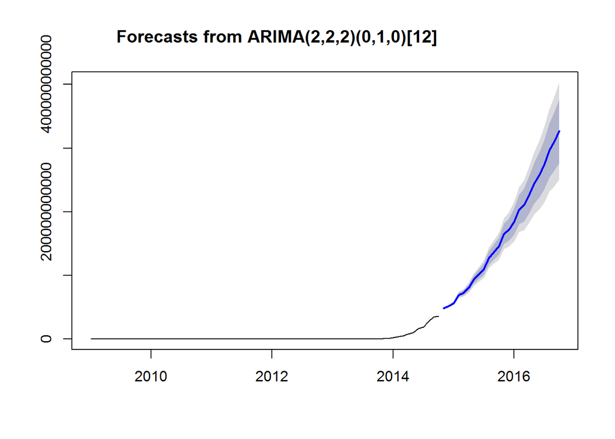

This data can then be used to estimate future profitability, based on the current hashrate of the mining hardware and the forecasted difficulty by using the following equation[^8]:

**BTC earned per day = Block Reward / (Difficulty * 2^32 / Hashrate / seconds in a day)**

Where:  
1. Block Reward is currently 25.  
2. Difficulty is the current or forecasted difficult.  
3. 2 * 2^32 is a constant.  
4. Hashrate is the current hashrate from the mining equipment.  
5. Seconds in a day is 86400 (1 * 60 * 60 * 24).

### Conclusion

By using the difficulty forecast, current hashrate of the mining equipment and the profitability equation, the estimated amount of Bitcoins earned per month can be predicted.

```r
## Calculating the predicted Hash Rate (assumes forcastng has
## been done "fcast") in a data frame.
## since fcast is it's own object, extract the date in a
## manipulatable foramt for lubridate.
tmp <- as.data.frame(fcast)
## Unfortunately the dates are as factors
d <- as.data.frame(lapply(row.names(tmp), as.character),
                   stringsAsFactors = FALSE) ##date as character
## Create the final index of dates
iDates <- mdy(d)

## Perform the same as above to extract the index of forecasted hasrates.
iForecast <- tmp[, 1]

## Create the output Table
x <- 4.363 ##sample hashrate TH/s
## Convert to kH/s
x <- x * 1000000000000
Table <- data.frame(Date = as.Date(character()),
                    Difficulty = numeric(),
                    Btc = numeric(),
                    Total = numeric(),
                    stringsAsFactors = FALSE)
names(Table) <- c("Date", "Difficulty Forecast", "Estimated Btc/Month",
                  "Total Accumulated Btc")
## Populate the first row of the Table
Table[1, 1] <- iDates[1]
Table[1, 2] <- iForecast[1]
Table[1, 3] <- 25/(iForecast[1] * 2^32/x/86400) * days_in_month(Table[1,1])[[1]]
Table[1, 4] <- Table[1, 3]

## Apply the above format into a loop
for (i in 2:length(iForecast)) {
        Table[i, 1] <- iDates[i]
        Table[i, 2] <- iForecast[i]
        Table[i, 3] <- 25/(iForecast[i] * 2^32/x/86400) * days_in_month(Table[i, 1])[[1]]
        Table[i, 4] <- Table[i, 3] + Table[i-1, 4]
}
```

Below is an example of the results using **4.363 TH/s**.

```
##          Date Difficulty Forecast Estimated Btc/Month
## 1  2014-11-20         48365626870           1.3610170
## 2  2014-12-20         52153751159           1.3042332
## 3  2015-01-20         56395199463           1.2061426
## 4  2015-02-20         69182084441           0.8880624
## 5  2015-03-20         72766109760           0.9347848
## 6  2015-04-20         80821580678           0.8144661
## 7  2015-05-20         93223712833           0.7296497
## 8  2015-06-20        101694497308           0.6472960
## 9  2015-07-20        110082830881           0.6179043
## 10 2015-08-20        127406641928           0.5338862
## 11 2015-09-20        136951849782           0.4806539
## 12 2015-10-20        145697600279           0.4668619
## 13 2015-11-20        165465479527           0.3978258
## 14 2015-12-20        172100366769           0.3952383
```

[output cut: 35 more lines]

### References

[^1]: https://en.bitcoin.it/wiki/Target
[^2]: https://bitcoinhelp.net/know/how-bitcoin-works
[^3]: https://en.bitcoin.it/wiki/Difficulty
[^4]: http://www.R-project.org
[^5]: http://blockexplorer.com
[^6]: http://robjhyndman.com/papers/automatic-forecasting/
[^7]: https://www.otexts.org/fpp/8/7
[^8]: https://en.bitcoin.it/wiki/Difficulty